# R Notebook

# 8.16 Barplots

to generate a barplot we can use the *geom_bar* geometry. the default is to count the number of each category and draw a bar. here is the plot for the regions of the US.

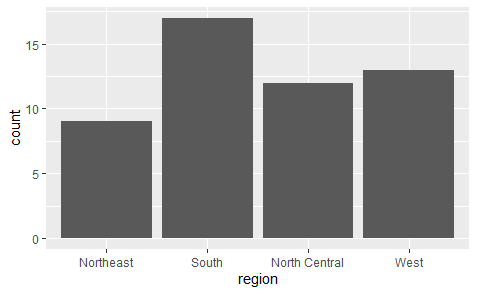

```r
murders %>% ggplot(aes(region))+ geom_bar()
```

we often already have a table with a distribution that we want to present as a barplot. here is an example of such a table:

```r
data("murders")
tab<- murders %>% count(region) %>% mutate(proportion = n/sum(n))
tab
```

| region | n | proportion |
| --- | --- | --- |
| Northeast | 9 | 0.1764706 |
| South | 17 | 0.3333333 |
| North Central | 12 | 0.2352941 |
| West | 13 | 0.2549020 |

we no longer want *geom_bar* to count, but rather just plot a bar to the height provided by the *proportion* variable. for this we need to provide x and y and use the *stat=“identity”* option.

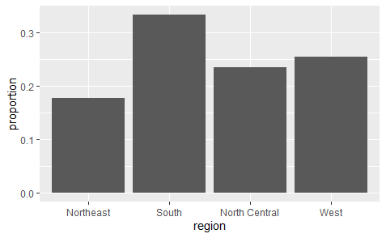

```r
tab %>% ggplot(aes(region, proportion)) +geom_bar(stat = "identity")
```

# 8.16.2 histograms

to generate histograms we use *geom_histogram*. by looking at the help file for this function, we learn that the only required argument is x, the variable for which we will construct a histogram. we dropped the x becuase we know it is the first argument. the code looks like this:

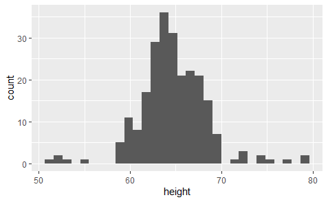

```r
heights %>%
  filter(sex == "Female") %>%
  ggplot(aes(height)) + geom_histogram()
```

if we run the code above, it gives us a message. we previously used a bin size of 1 inch, so the code like like this.

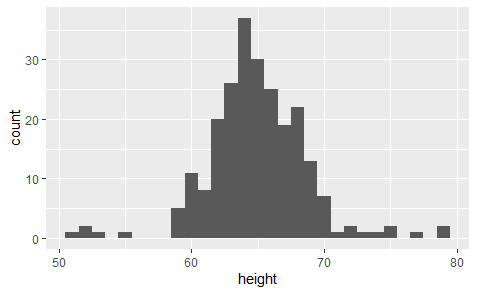

```r
heights %>%
  filter(sex == "Female") %>%
  ggplot(aes(height))+ geom_histogram(binwidth = 1)
```

finally, if for aesthetic reasons we want to add color, we use the arguments described in the help file. we also add labels and a title:

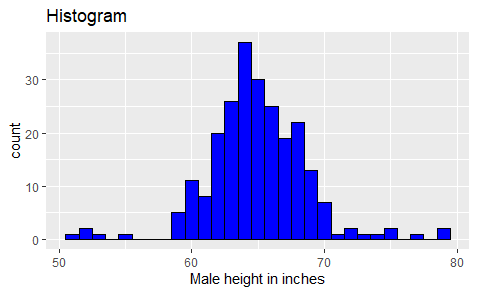

```r
heights %>%
  filter(sex == "Female") %>%
  ggplot(aes(height))+ geom_histogram(binwidth = 1, fill="blue", col="black")+xlab("Male height in inches")+ggtitle("Histogram")
```

# 8.16.3 density plots

to create a smooth density, we use the *geom_density*. to make a smooth density plot with the data previously shown as a histogram we can use this code:

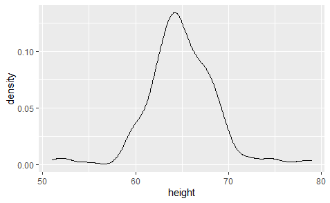

```r
heights %>%
  filter(sex == "Female") %>%
  ggplot(aes(height))+ geom_density()
```

to fill in with color, we can use the *fill* argument.

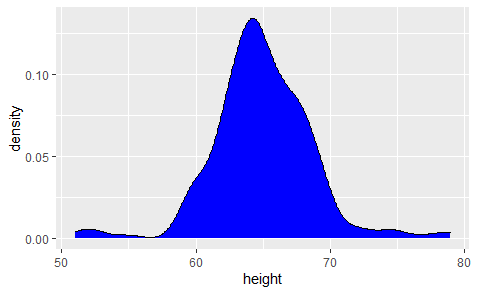

```r
heights %>%
  filter(sex == "Female") %>%
  ggplot(aes(height))+ geom_density(fill="blue")
```

to change the smoothness of the density, we use the *adjust* argument to multiply the default value by the adjust. for example, if we want the bandwidth to be twice as big we use:

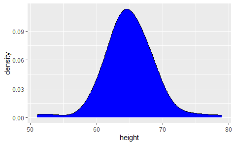

```r
heights %>%
  filter(sex == "Female") %>%
  ggplot(aes(height))+ geom_density(fill="blue", adjust=2)
```